# Cancer Mortality

- Show All Code
- Hide All Code
- View Source

Author

Prof. Tang

Published

March 3, 2026

```python
import os
from os.path import join as oj
import pandas as pd
from sklearn.model_selection import train_test_split
from sklearn.linear_model import LinearRegression, LassoCV
from sklearn.ensemble import RandomForestRegressor
from sklearn.metrics import r2_score, mean_absolute_error, root_mean_squared_error
from plotnine import ggplot, aes, geom_histogram, labs, theme_classic, \
  geom_point, facet_wrap, theme, element_text
import seaborn as sns
from matplotlib import pyplot as plt

DATA_DIR = oj("..", "data")
RESULTS_DIR = oj("..", "results")
# DATA_DIR = oj("data")
# RESULTS_DIR = oj("results")
```

## Load in Cancer Mortality Data

In this analysis, let’s explore a cancer mortality dataset collected by the National Cancer Institute (NCI) and the Centers for Disease Control and Prevention (CDC). The dataset contains information on cancer mortality rates and various demographic, socioeconomic, and health-related factors for different U.S. counties.

```python
cancer_train_orig = pd.read_csv(
  oj(DATA_DIR, "cancer_train.csv"), encoding="ISO-8859-1"
)
cancer_test_orig = pd.read_csv(
  oj(DATA_DIR, "cancer_test.csv"), encoding="ISO-8859-1"
)
```

A brief description of the variables in the dataset is as follows:

- `TARGET_deathRate`: Dependent variable of interest. Cancer mortality rate per 100,000 people.
- `Geography`: Name of the county and state.
- `incidenceRate`: Cancer diagnosis (incidence) rate per 100,000 people.
- `popEst2015`: Estimated population in 2015.
- `BirthRate`: Number of live births relative to number of women in county.
- `medIncome`: Median household income.
- `povertyPercent`: Percentage of populace below the poverty line.
- `studyPerCap`: Number of cancer-related clinical trials per capita.
- `MedianAge`: Median age of the population.
- `MedianAgeMale`: Median male age of the population.
- `MedianAgeFemale`: Median female age of the population.
- `AvgHouseholdSize`: Average household size.
- `PercentMarried`: Percentage of residents who are married.
- `PctEmployed16_Over`: Percentage of residents ages 16 and over who are employed.
- `PctUnemployed16_Over`: Percentage of residents ages 16 and over who are unemployed.
- `PctWhite`: Percentage of residents who identify as White.
- `PctBlack`: Percentage of residents who identify as Black.
- `PctAsian`: Percentage of residents who identify as Asian.
- `PctOtherRace`: Percentage of residents who identify in a category which is not White, Black, or Asian.

This is a subset of the larger cancer mortality dataset, which contains more variables. We have removed some variables for the sake of simplicity and demonstration. If you would like to go back and use this larger dataset, you can instead load in the `cancer_train_full.csv` and `cancer_test_full.csv` files, which contain the full set of variables with data dictionary available [here](https://www.kaggle.com/datasets/gurtegsawhney/cancer-death-rates-data).

Some quick and helpful snapshots of the training data:

**print()**

```python
cancer_train_orig
```

|  | TARGET_deathRate | Geography | incidenceRate | popEst2015 | BirthRate | medIncome | povertyPercent | studyPerCap | MedianAge | MedianAgeMale | MedianAgeFemale | AvgHouseholdSize | PercentMarried | PctEmployed16_Over | PctUnemployed16_Over | PctWhite | PctBlack | PctAsian | PctOtherRace |
| --- | --- | --- | --- | --- | --- | --- | --- | --- | --- | --- | --- | --- | --- | --- | --- | --- | --- | --- | --- |
| 0 | 164.9 | Kitsap County, Washington | 489.800000 | 260131 | 6.118831 | 61898 | 11.2 | 499.748204 | 39.3 | 36.9 | 41.7 | 2.54 | 52.5 | 51.9 | 8.0 | 81.780529 | 2.594728 | 4.821857 | 1.843479 |
| 1 | 161.3 | Kittitas County, Washington | 411.600000 | 43269 | 4.333096 | 48127 | 18.6 | 23.111234 | 33.0 | 32.2 | 33.7 | 2.34 | 44.5 | 55.9 | 7.8 | 89.228509 | 0.969102 | 2.246233 | 3.741352 |
| 2 | 174.7 | Klickitat County, Washington | 349.700000 | 21026 | 3.729488 | 49348 | 14.6 | 47.560164 | 45.0 | 44.0 | 45.8 | 2.62 | 54.2 | 45.9 | 7.0 | 90.922190 | 0.739673 | 0.465898 | 2.747358 |
| 3 | 176.0 | Mason County, Washington | 505.400000 | 61023 | 4.964476 | 52313 | 15.6 | 180.259902 | 45.4 | 43.5 | 48.0 | 2.58 | 50.4 | 44.1 | 12.9 | 84.882631 | 1.653205 | 1.538057 | 3.314635 |
| 4 | 175.9 | Okanogan County, Washington | 461.800000 | 41516 | 4.204317 | 37782 | 23.2 | 0.000000 | 42.6 | 42.2 | 43.5 | 2.42 | 54.1 | 51.8 | 8.9 | 75.106455 | 0.616955 | 0.866157 | 8.356721 |
| ... | ... | ... | ... | ... | ... | ... | ... | ... | ... | ... | ... | ... | ... | ... | ... | ... | ... | ... | ... |
| 2415 | 146.4 | Ellis County, Kansas | 453.549422 | 29029 | 3.977583 | 49508 | 13.0 | 723.414516 | 32.2 | 31.0 | 33.8 | 2.35 | 45.1 | 68.6 | 4.5 | 94.291726 | 1.145104 | 1.386542 | 1.014038 |
| 2416 | 149.6 | Ellsworth County, Kansas | 453.549422 | 6343 | 7.773512 | 46961 | 12.4 | 0.000000 | 44.2 | 41.1 | 48.8 | 2.08 | 51.0 | 51.7 | 4.3 | 90.280811 | 3.837754 | 0.327613 | 1.700468 |
| 2417 | 150.1 | Finney County, Kansas | 453.549422 | 37118 | 8.186470 | 48609 | 18.8 | 377.175494 | 30.4 | 29.3 | 31.4 | 2.90 | 52.6 | 70.1 | 4.6 | 75.706245 | 2.326771 | 4.044920 | 14.130288 |
| 2418 | 153.9 | Ford County, Kansas | 453.549422 | 34536 | 7.809192 | 51144 | 15.0 | 1968.959926 | 30.9 | 30.5 | 31.2 | 3.04 | 54.8 | 64.8 | 6.4 | 87.961629 | 2.313188 | 1.316472 | 5.680705 |
| 2419 | 175.0 | Franklin County, Kansas | 453.549422 | 25609 | 7.582938 | 50745 | 13.3 | 0.000000 | 39.0 | 36.9 | 40.5 | 2.56 | 58.8 | NaN | 6.9 | 92.905681 | 1.176562 | 0.244632 | 2.131790 |

2420 rows × 19 columns

**info()**

```python
cancer_train_orig.info()
```

```
<class 'pandas.core.frame.DataFrame'>
RangeIndex: 2420 entries, 0 to 2419
Data columns (total 19 columns):
 #   Column                Non-Null Count  Dtype
---  ------                --------------  -----
 0   TARGET_deathRate      2420 non-null   float64
 1   Geography             2420 non-null   object
 2   incidenceRate         2420 non-null   float64
 3   popEst2015            2420 non-null   int64
 4   BirthRate             2420 non-null   float64
 5   medIncome             2420 non-null   int64
 6   povertyPercent        2420 non-null   float64
 7   studyPerCap           2420 non-null   float64
 8   MedianAge             2420 non-null   float64
 9   MedianAgeMale         2420 non-null   float64
 10  MedianAgeFemale       2420 non-null   float64
 11  AvgHouseholdSize      2420 non-null   float64
 12  PercentMarried        2420 non-null   float64
 13  PctEmployed16_Over    2306 non-null   float64
 14  PctUnemployed16_Over  2420 non-null   float64
 15  PctWhite              2420 non-null   float64
 16  PctBlack              2420 non-null   float64
 17  PctAsian              2420 non-null   float64
 18  PctOtherRace          2420 non-null   float64
dtypes: float64(16), int64(2), object(1)
memory usage: 359.3+ KB
```

**describe()**

```python
cancer_train_orig.describe()
```

|  | TARGET_deathRate | incidenceRate | popEst2015 | BirthRate | medIncome | povertyPercent | studyPerCap | MedianAge | MedianAgeMale | MedianAgeFemale | AvgHouseholdSize | PercentMarried | PctEmployed16_Over | PctUnemployed16_Over | PctWhite | PctBlack | PctAsian | PctOtherRace |
| --- | --- | --- | --- | --- | --- | --- | --- | --- | --- | --- | --- | --- | --- | --- | --- | --- | --- | --- |
| count | 2420.000000 | 2420.000000 | 2.420000e+03 | 2420.000000 | 2420.000000 | 2420.000000 | 2420.000000 | 2420.000000 | 2420.000000 | 2420.000000 | 2420.000000 | 2420.000000 | 2306.000000 | 2420.000000 | 2420.000000 | 2420.000000 | 2420.000000 | 2420.000000 |
| mean | 178.439917 | 448.212005 | 1.016093e+05 | 5.655674 | 47177.582231 | 16.798223 | 151.335183 | 40.840868 | 39.585041 | 42.154835 | 2.476912 | 51.923058 | 54.226843 | 7.792645 | 83.838113 | 9.096704 | 1.227053 | 1.975963 |
| std | 27.549085 | 52.843978 | 3.377882e+05 | 2.004248 | 12145.405088 | 6.434142 | 494.411616 | 5.190003 | 5.230337 | 5.274565 | 0.434828 | 6.860788 | 8.292787 | 3.429886 | 16.230212 | 14.650109 | 2.544983 | 3.521487 |
| min | 59.700000 | 211.100000 | 8.270000e+02 | 0.000000 | 22640.000000 | 3.200000 | 0.000000 | 23.200000 | 22.800000 | 22.300000 | 0.022100 | 25.100000 | 17.600000 | 0.400000 | 10.199155 | 0.000000 | 0.000000 | 0.000000 |
| 25% | 161.200000 | 420.800000 | 1.171200e+04 | 4.541572 | 38797.250000 | 12.000000 | 0.000000 | 37.700000 | 36.400000 | 39.000000 | 2.360000 | 48.100000 | 48.600000 | 5.500000 | 77.495894 | 0.620736 | 0.254354 | 0.294758 |
| 50% | 177.800000 | 453.549422 | 2.630950e+04 | 5.377821 | 45347.000000 | 15.800000 | 0.000000 | 41.000000 | 39.600000 | 42.400000 | 2.500000 | 52.700000 | 54.600000 | 7.500000 | 90.294913 | 2.235069 | 0.552789 | 0.806694 |
| 75% | 195.300000 | 480.550000 | 6.663525e+04 | 6.530228 | 52664.750000 | 20.400000 | 79.957915 | 43.900000 | 42.600000 | 45.300000 | 2.630000 | 56.500000 | 60.400000 | 9.700000 | 95.468942 | 10.285576 | 1.206995 | 2.151820 |
| max | 293.900000 | 1014.200000 | 1.017029e+07 | 21.326165 | 125635.000000 | 47.400000 | 8585.924288 | 65.300000 | 64.700000 | 65.700000 | 3.970000 | 72.500000 | 76.500000 | 29.400000 | 99.845905 | 85.947799 | 42.619425 | 41.930251 |

Some observations based upon these quick explorations:

- There is one qualitative variable (i.e., `Geography`).
- There is one variable (i.e., `PctEmployed16_Over`) with missing values.
  - How can we deal with such missingness? Options include:
    1. Impute missing values using mean, median, mode, or other imputation methods.
    2. Remove observations (i.e., rows) with too many missing values.
    3. Remove variables (i.e., columns) with too many missing values. *We will do this since `PctEmployed16_Over` is likely redundant given `PctUnemployed16_Over`.*

## Data Cleaning

We will next perform some data cleaning steps to prepare the data for analysis. Specifically, we will

- Deal with missing values by removing variables/columns with missing values. We chose this approach since there is only one variable with missing values and it is likely redundant given that we have `PctUnemployed16_Over`.

Other data cleaning steps could also be taken, but we will keep it simple for now.

```python
# get names of variables/columns with missing values
na_vars = cancer_train_orig.columns[cancer_train_orig.isna().any()].tolist()
# remove variables/columns with missing values
cancer_train = cancer_train_orig.loc[:, ~cancer_train_orig.columns.isin(na_vars)]
cancer_test = cancer_test_orig.loc[:, ~cancer_test_orig.columns.isin(na_vars)]

# move Geography to row names and remove Geography column
cancer_train.index = cancer_train["Geography"]
cancer_train = cancer_train.drop(columns = "Geography")
cancer_test.index = cancer_test["Geography"]
cancer_test = cancer_test.drop(columns = "Geography")
```

Let’s take a look at the cleaned data:

```python
cancer_train
```

| Geography | TARGET_deathRate | incidenceRate | popEst2015 | BirthRate | medIncome | povertyPercent | studyPerCap | MedianAge | MedianAgeMale | MedianAgeFemale | AvgHouseholdSize | PercentMarried | PctUnemployed16_Over | PctWhite | PctBlack | PctAsian | PctOtherRace |
| --- | --- | --- | --- | --- | --- | --- | --- | --- | --- | --- | --- | --- | --- | --- | --- | --- | --- |
| Kitsap County, Washington | 164.9 | 489.800000 | 260131 | 6.118831 | 61898 | 11.2 | 499.748204 | 39.3 | 36.9 | 41.7 | 2.54 | 52.5 | 8.0 | 81.780529 | 2.594728 | 4.821857 | 1.843479 |
| Kittitas County, Washington | 161.3 | 411.600000 | 43269 | 4.333096 | 48127 | 18.6 | 23.111234 | 33.0 | 32.2 | 33.7 | 2.34 | 44.5 | 7.8 | 89.228509 | 0.969102 | 2.246233 | 3.741352 |
| Klickitat County, Washington | 174.7 | 349.700000 | 21026 | 3.729488 | 49348 | 14.6 | 47.560164 | 45.0 | 44.0 | 45.8 | 2.62 | 54.2 | 7.0 | 90.922190 | 0.739673 | 0.465898 | 2.747358 |
| Mason County, Washington | 176.0 | 505.400000 | 61023 | 4.964476 | 52313 | 15.6 | 180.259902 | 45.4 | 43.5 | 48.0 | 2.58 | 50.4 | 12.9 | 84.882631 | 1.653205 | 1.538057 | 3.314635 |
| Okanogan County, Washington | 175.9 | 461.800000 | 41516 | 4.204317 | 37782 | 23.2 | 0.000000 | 42.6 | 42.2 | 43.5 | 2.42 | 54.1 | 8.9 | 75.106455 | 0.616955 | 0.866157 | 8.356721 |
| ... | ... | ... | ... | ... | ... | ... | ... | ... | ... | ... | ... | ... | ... | ... | ... | ... | ... |
| Ellis County, Kansas | 146.4 | 453.549422 | 29029 | 3.977583 | 49508 | 13.0 | 723.414516 | 32.2 | 31.0 | 33.8 | 2.35 | 45.1 | 4.5 | 94.291726 | 1.145104 | 1.386542 | 1.014038 |
| Ellsworth County, Kansas | 149.6 | 453.549422 | 6343 | 7.773512 | 46961 | 12.4 | 0.000000 | 44.2 | 41.1 | 48.8 | 2.08 | 51.0 | 4.3 | 90.280811 | 3.837754 | 0.327613 | 1.700468 |
| Finney County, Kansas | 150.1 | 453.549422 | 37118 | 8.186470 | 48609 | 18.8 | 377.175494 | 30.4 | 29.3 | 31.4 | 2.90 | 52.6 | 4.6 | 75.706245 | 2.326771 | 4.044920 | 14.130288 |
| Ford County, Kansas | 153.9 | 453.549422 | 34536 | 7.809192 | 51144 | 15.0 | 1968.959926 | 30.9 | 30.5 | 31.2 | 3.04 | 54.8 | 6.4 | 87.961629 | 2.313188 | 1.316472 | 5.680705 |
| Franklin County, Kansas | 175.0 | 453.549422 | 25609 | 7.582938 | 50745 | 13.3 | 0.000000 | 39.0 | 36.9 | 40.5 | 2.56 | 58.8 | 6.9 | 92.905681 | 1.176562 | 0.244632 | 2.131790 |

2420 rows × 17 columns

## Data Splitting

We next split the training data into two parts: a training set (e.g., 75% of the data) and a validation set (e.g., 25% of the data). The training set would be used to build and tune our models while the validation set would be used to perform model selection. Note: we are also given a separate test set (`cancer_test.csv`), which will eventually be used to evaluate our selected model’s prediction performance and obtain an unbiased estimate of the model’s generalization error.

```python
# split training data into two parts: training and validation
X = cancer_train.drop(columns = "TARGET_deathRate")
y = cancer_train["TARGET_deathRate"]
X_train, X_valid, y_train, y_valid = train_test_split(
  X, y, test_size = 0.25, random_state = 123
)
```

## Exploratory Data Analysis

Before modeling, it is also important to visualize and understand our data through an exploratory data analysis (EDA). At a minimum, it is generally good practice to visualize

1. the distribution of the response variable,
2. the distribution of the predictor variables,
3. the correlation between the predictor variables, and
4. the relationship between the response variable and each predictor variable.

Throughout this EDA, we will use the training portion of the data (`cancer_train`) to avoid any potential data leakage (or “data snooping”).

**Y Distribution**

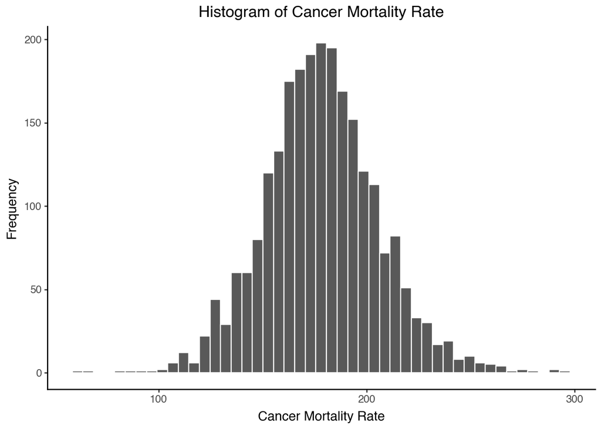

```python
ggplot(cancer_train) +\
  aes(x = "TARGET_deathRate") +\
  geom_histogram(color = "white") +\
  labs(
    x = "Cancer Mortality Rate",
    y = "Frequency",
    title = "Histogram of Cancer Mortality Rate"
  ) +\
  theme_classic()
```

**X Distributions**

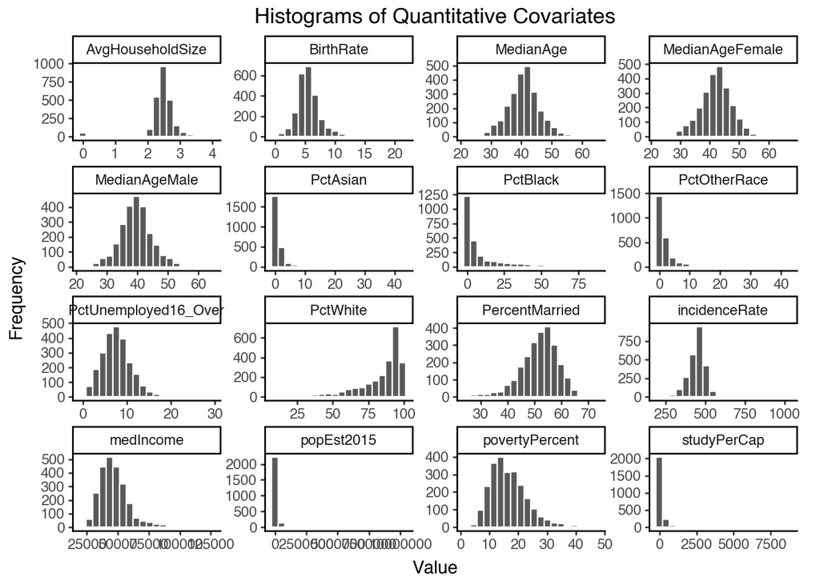

```python
# convert cancer data from "wide" format to "long" format for ggplot
plt_df = cancer_train.melt(
  id_vars = "TARGET_deathRate", var_name = "variable", value_name = "value"
)
ggplot(plt_df) +\
  aes(x = "value") +\
  geom_histogram(color = "white", bins = 20) +\
  facet_wrap("~ variable", scales = "free", ncol = 4) +\
  labs(
    x = "Value",
    y = "Frequency",
    title = "Histograms of Quantitative Covariates"
  ) +\
  theme_classic()
```

**Correlations**

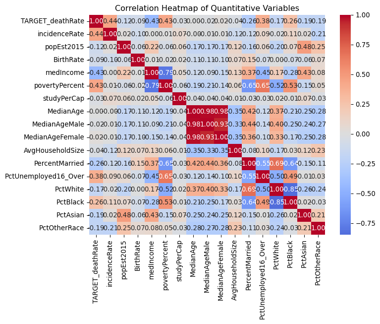

```python
plt.figure(figsize=(8, 6))
sns.heatmap(cancer_train.corr(), annot = True, fmt = ".2f", cmap = "coolwarm", center = 0)
plt.title("Correlation Heatmap of Quantitative Variables")
plt.show()
```

**Relationship Between Response and Predictors**

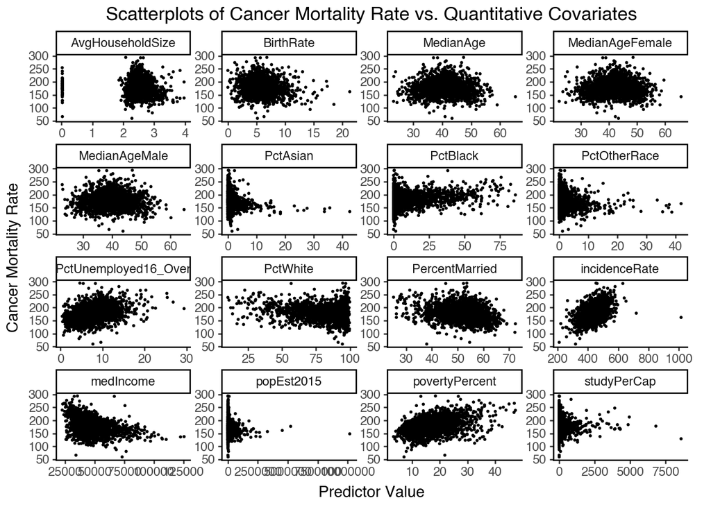

```python
# convert cancer data from "wide" format to "long" format for ggplot
plt_df = cancer_train.melt(
  id_vars = "TARGET_deathRate", var_name = "variable", value_name = "value"
)
ggplot(plt_df) +\
  aes(x = "value", y = "TARGET_deathRate") +\
  geom_point(size = 0.25) +\
  facet_wrap("~ variable", scales = "free", ncol = 4) +\
  labs(
    x = "Predictor Value",
    y = "Cancer Mortality Rate",
    title = "Scatterplots of Cancer Mortality Rate vs. Quantitative Covariates"
  ) +\
  theme_classic()
```

## Modeling

For the sake of demonstration, we will fit a linear regression model, a LASSO regression model, and a random forest model to predict cancer mortality rates.

```python
# models
models_dict = {
  "OLS": LinearRegression(),
  "LASSO": LassoCV(cv = 5, random_state = 123),
  "RF": RandomForestRegressor(
    n_estimators = 500,
    max_features = "sqrt",
    min_samples_leaf = 5,
    random_state = 123
  )
}

# evaluation metrics
metrics_dict = {
  "RMSE": root_mean_squared_error,
  "R2": r2_score,
  "MAE": mean_absolute_error
}

# fit models on training data and evaluate on validation data
valid_metrics_ls = []
for model_name, model in models_dict.items():
  model.fit(X_train, y_train)
  preds_valid = model.predict(X_valid)
  for metric_name, metric_func in metrics_dict.items():
    metric_value = metric_func(y_valid, preds_valid)
    valid_metrics_ls.append({
      "model": model_name,
      "metric": metric_name,
      "value": metric_value
    })

valid_metrics_df = pd.DataFrame(valid_metrics_ls).pivot(index = "model", columns = "metric", values = "value")
print(valid_metrics_df)
```

```
metric        MAE        R2       RMSE
model
LASSO   19.447745  0.188272  25.088313
OLS     16.050777  0.417121  21.259606
RF      14.865662  0.486565  19.953035
```

## Prediction on test set

```python
# re-fit best model on all training data (i.e., training + validation)
best_model = RandomForestRegressor(
  n_estimators = 500,
  max_features = "sqrt",
  min_samples_leaf = 5,
  random_state = 123
)
best_model.fit(X, y)

# predict on test set
preds_test = best_model.predict(cancer_test)

# save predictions to file
if not os.path.exists(RESULTS_DIR):
  os.makedirs(RESULTS_DIR)
pd.DataFrame(preds_test, columns = ["TARGET_deathRate"]).to_csv(
  oj(RESULTS_DIR, "test_predictions.csv"), index = False
)
```

```python
# # TODO: UNCOMMENT LATER AND REMOVE `eval: false` TO EVALUATE TEST PREDICTIONS
# # read in true test labels
# test_labels = pd.read_csv(
#   oj(DATA_DIR, "cancer_test_labels.csv")
# )
# # compute test metrics
# test_metrics = {
#   metric_name: metric_func(test_labels["TARGET_deathRate"], preds_test)
#   for metric_name, metric_func in metrics_dict.items()
# }
# print(test_metrics)
```